# 🧠 Estatística Bayesiana Aplicada à Saúde

## 🎯 Objetivos

1. Calcular a probabilidade de uma condição a partir de acertos, falsos positivos e taxas base usando um diagrama de árvore.
2. Calcular a probabilidade de uma condição usando o Teorema de Bayes.
3. Compreender como as taxas base impactam a probabilidade condicional.
4. Calcular probabilidades com base em um diagrama de árvore.
5. Calcular probabilidades com base no Teorema de Bayes.

https://prezi.com/p/efwgm5awfq7h/?present=1

## 📝 Introdução

A **Estatística Bayesiana** difere da **Estatística Frequentista** na forma de interpretar a probabilidade. Enquanto a estatística frequentista entende a probabilidade como uma frequência relativa ao longo de experimentos repetidos, a estatística bayesiana considera a probabilidade como uma **medida de crença** ou **confiança** sobre um evento.

A estatística bayesiana parte do princípio de que podemos atualizar nossa crença conforme novas evidências são apresentadas. Isso significa que, ao realizar um teste diagnóstico e obter um resultado positivo, podemos revisar nossa crença inicial (probabilidade a priori) à luz da nova informação (probabilidade condicional).

A abordagem bayesiana reconhece que a incerteza é intrínseca ao conhecimento e, portanto, as probabilidades representam graus de crença ou confiança. A cada nova evidência, podemos revisar nossa estimativa de probabilidade, movendo-nos de um estado de conhecimento incerto para um estado de conhecimento atualizado e mais informado.

A estatística bayesiana é particularmente poderosa em situações em que há uma **probabilidade pré-existente** (a priori) e precisamos ajustá-la com base em novos dados (a posteriori). Isso faz dela uma ferramenta essencial para a **análise diagnóstica em saúde**, onde precisamos constantemente revisar nossas expectativas com base em novos exames e testes clínicos.

## 📈 Teorema de Bayes

O teorema de Bayes nos ajuda a calcular a probabilidade condicional considerando tanto a **probabilidade a priori** quanto o **valor diagnóstico do teste**.

A dedução do teorema vem do seguinte: A expressão original parte da definição de probabilidade condicional:

$\Pr(A| B) = \frac{Pr (A ∩ B)}{P (B)}$

Da mesma forma:

$\Pr(B | A) = \frac{Pr (A ∩ B)}{P (A)}$

Multiplicando ambos os lados por P(B) e P(A), temos:

$\Pr(A ∩ B) = P(A) * Pr(B|A) = P(B) * Pr(A|B) $

Portanto

$\Pr(A | B) = \frac{Pr (A) * Pr(B|A)}{P (B)}$

Calcula a probabilidade condicional de 𝐴 dado 𝐵 utilizando a probabilidade reversa (𝐵∣𝐴).

Em muitos casos da vida real (especialmente em estatística e probabilidade) coletar diretamente a probabilidade condicional desejada (𝑃(𝐴+∣𝐵+) pode ser difícil ou impraticável. No entanto, é mais fácil obter a probabilidade reversa (𝑃(𝐵+∣𝐴+) por meio de pesquisas ou estudos específicos.

O Teorema de Bayes existe justamente para lidar com situações em que a probabilidade desejada (𝑃(𝐴+∣𝐵+) não é diretamente acessível, mas podemos obter a probabilidade reversa (𝑃(𝐵+∣𝐴+) por meio de pesquisas, estudos ou levantamentos.

**Exemplo**

📊 **Matriz de Confusão para o Teste de Câncer de Mama**

| Resultado do Teste | **Câncer (1%) - 100** | **Não Câncer (99%) - 9.900** | **Total** |
| --- | --- | --- | --- |
| **Positivo (T+)** | 80 (80% de 100) | 950 (9,6% de 9.900) | 1.030 |
| **Negativo (T-)** | 20 (20% de 100) | 8.950 (90,4% de 9.900) | 8.970 |
| **Total** | 100 | 9.900 | 10.000 |

Dado um teste positivo, qual é a probabilidade de a mulher realmente ter câncer?

Teorema de Bayes: P(C|T) probabilidade de ter câncer (C+) após um teste positivo (T+) ou seja (C+|T+) = probabilidade de ter câncer (C+) vezes probabilidade de um um teste positivo (T+) dado que tem câncer (T+|C+) dividido pela probabilidade de um teste positivo (T+)

$\Pr( D+ | T +) = \frac{Pr (D+) * Pr(T+|D+)}{P(T+)}$

Teste positivo pode ocorrer em dois cenários (Regra da Probabilidade total):

- Probabilidade de ter um teste positivo (T+) = probabilidade de ter câncer (C+) * probabilidade de ter um teste positivo dado que tem câncer (T+|C+) + probabilidade de não ter câncer (C-) * probabilidade de ter um teste positivo dado que não tem câncer (T+|C-)

```python
# Probabilidades fornecidas
p_c = 0.01         # Prevalência de câncer (1%)
p_nao_c = 1 - p_c  # Probabilidade de não ter câncer (99%)
p_t_c = 0.80       # Sensibilidade (teste positivo dado câncer)
p_t_nao_c = 0.096  # Falso positivo (teste positivo dado que não tem câncer)

p_c_t = (p_c * p_t_c) / ((p_c * p_t_c) + (p_nao_c * p_t_nao_c))

print(f"Probabilidade de ter câncer após um teste positivo: {p_c_t:.2%}")
```

```
Probabilidade de ter câncer após um teste positivo: 7.76%
```

## 📍 Chance ou Odds

Chance (Odds) é uma medida usada para expressar a probabilidade de um evento ocorrer em relação à probabilidade de ele não ocorrer. É um conceito bastante utilizado em estatística, epidemiologia e análise de testes diagnósticos.

$Chance = \frac{Probabilidade}{1 - Probabilidade}$

- Se a chance for igual a 1, significa que a probabilidade de o evento acontecer e não acontecer são iguais (50% para cada lado).
- Se a chance for maior que 1, significa que o evento é mais provável do que o não evento.
- Se a chance for menor que 1, significa que o evento é menos provável do que o não evento.

**Exemplo**

Imagine que a probabilidade de um paciente ter uma determinada doença seja de 20% (0,20). A chance seria calculada como:

```python
probabilidade = 0.2

chance = probabilidade / (1 - probabilidade)

print(f"A chance, dada a probabilidade de 0.2, é: {chance:.2f}")
```

```
A chance, dada a probabilidade de 0.2, é: 0.25
```

Isso significa que as odds de ter a doença são de 0,25 (ou 1 para 4), ou seja, para cada 1 caso de doença, há 4 casos sem a doença.

## 📏 Razão de Verossimilhança

No contexto de testes diagnósticos, a chance é usada para calcular a Chance Pós-teste com base na Razão de Verossimilhança e na Chance Pré-teste. Isso ajuda a atualizar a probabilidade de um diagnóstico após o resultado de um teste clínico.

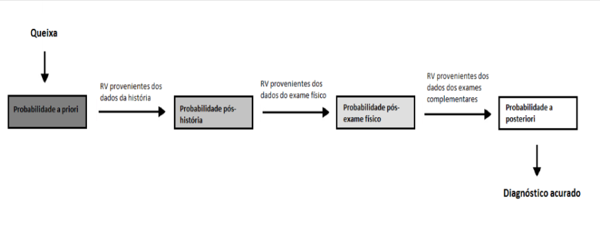

A cada passo, adiciona-se evidência à hipótese, de modo que, como demonstra a imagem, sequencialmente as "coisas vão como clareando" à luz da ciência (Summerton, 2015)

A Razão de Verossimilhança (RV) é uma medida que combina a sensibilidade e a especificidade de um teste diagnóstico para indicar o quanto o resultado do teste modifica a probabilidade pré-teste de uma condição estar presente. A RV nos ajuda a avaliar o impacto de um teste positivo ou negativo no diagnóstico.

Para entender como a Razão de Verossilhança pode ser derivada, pensemos em uma tabela 2x2

|  | Doente (D+) | Não Doente (D-) |
| --- | --- | --- |
| **Teste + (T+)** | A | B |
| **Teste - (T-)** | C | D |

Dessa tabela já sabemos que os conceitos de especificidade e sensibilidade

$Sensibilidade = \frac{A}{A + C}$

$Especificidade = \frac{D}{B + D}$

#### Razão de verosimilhança positiva ou Positive Likelihood ratio

A Razão de Verossimilhança Positiva (RVP) é uma medida que indica o quanto um teste positivo aumenta a probabilidade de uma doença estar presente. Em outras palavras, ela responde à pergunta: "Dado um teste positivo, qual é a chance de a pessoa realmente ter a doença?"

A RVP é a razão entre a probabilidade de um resultado positivo em doentes e a probabilidade de um resultado positivo em não doentes:

$RVP = \frac{P(T+|D+)}{P(T+|D-)}$

A probabilidade de um teste positivo em doentes é a sensibilidade, assim como a probabilidade de um teste positivo em não doentes é o complemento da especificidade. Portanto:

$RVP = \frac{Sensibilidade}{1 - Especificidade}$

Assim, RVP indica quantas vezes um teste positivo é mais provável em indivíduos com a doença do que em indivíduos sem a doença. Um valor elevado de RVP indica que um teste positivo realmente aumenta a suspeita de doença, enquanto um valor baixo indica que o teste positivo não é muito útil para confirmar o diagnóstico.

Em resumo, quanto maior o valor da RVP, melhor é o teste para incluir a presença da doença.

```python
# Definindo a sensibilidade e a especificidade do teste
sensibilidade = 0.9  # Exemplo: 90% de probabilidade de teste positivo em indivíduos doentes
especificidade = 0.8  # Exemplo: 80% de probabilidade de teste negativo em indivíduos saudáveis

# Calculando a Razão de Verossimilhança Positiva (RVP)
rvp = sensibilidade / (1 - especificidade)

# Imprimindo o resultado
print(f"A Razão de Verossimilhança Positiva (RVP) é: {rvp}")
```

```
A Razão de Verossimilhança Positiva (RVP) é: 4.500000000000001
```

#### Razão de verosimilhança negativa ou Negative Likelihood ratio

A Razão de Verossimilhança Negativa (RVN) é uma medida que indica o quanto um teste negativo diminui a probabilidade de uma doença estar presente. Em outras palavras, ela responde à pergunta: "Dado um teste negativo, qual é a chance de a pessoa realmente não ter a doença?"

A RVN é a razão entre a probabilidade de um resultado negativo em doentes e a probabilidade de um resultado negativo em não doentes:

$RVN = \frac{P(T-|D+)}{P(T-|D-)}$

A probabilidade de um teste negativo em não doentes é a especificidade, assim como a probabilidade de um teste negativo em doentes é o complemento da sensibilidade. Portanto:

$RVN = \frac{1 - Sensibilidade}{Especificidade}$

```python
# Calculando a Razão de Verossimilhança Negativa (RVN)
rvn = (1 - sensibilidade) / especificidade

# Imprimindo o resultado
print(f"A Razão de Verossimilhança Negativa (RVN) é: {rvn}")
```

```
A Razão de Verossimilhança Negativa (RVN) é: 0.12499999999999997
```

A Razão de Verossimilhança Negativa (RVN) indica quantas vezes um teste negativo é mais provável em indivíduos com a doença do que em indivíduos sem a doença.

- Um valor baixo de RVN (próximo de 0) indica que um teste negativo realmente reduz a suspeita de doença, aumentando a confiança de que o paciente está saudável.
- Por outro lado, um valor alto de RVN (próximo de 1) significa que um teste negativo não é muito útil para descartar o diagnóstico, pois não reduz substancialmente a probabilidade da doença estar presente.

Em resumo, quanto menor o valor da RVN, melhor é o teste para excluir a presença da doença.

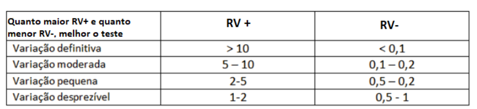

## 📎 Chance Pré-teste e Chance Pós-Teste

Pelo Teorema de Bayes sabemos que:

$\Pr( D+ | T +) = \frac{Pr (D+) * Pr(T+|D+)}{P(T+)}$

- Pr(D+|T+) = Probabilidade pós-teste (Probabilidade de estar doente dado um teste positivo).
- Pr(D+|T+) = Sensibilidade (Probabilidade de teste positivo dado que está doente).
- Pr(D+) = Prevalência
- Pr(T+) = Probabilidade de um teste positivo (seja doente ou não).

Como vimos no exercício, podemos substituir P(D+|T+) por sensibilidade. Assim como substituir P(T+) pela regra da adição de probabilidades por Sensibilidade * P(D+) + [(1 - especificidade) * P(D-)]

$\Pr( D+ | T +) = \frac{Pr (D+) * sensibilidade}{sensibilidade * P(D+) + [(1 - especificidade) * P(D-)]}$

Podemos simplificar a expressão dividindo tanto o numerador quanto o denominador por P(D-)

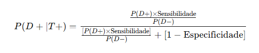

Mas, sabemos, pela probabilidade complementar que:

$P(D-) = 1 - P(D+)$

Então simplificando o numerador, temos:

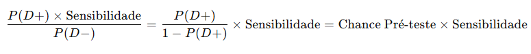

Isso porque, pela fórmula de chance, a chance pré-teste é:

$Chance pré-teste = \frac{P(D+)}{1 - P(D+)}$

Já o denominador, também podemos simplificar também fazendo a substituição de P(D-) pelo seu complementar e a substituição da chance pré-teste

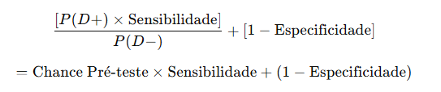

Expressando a fórmula final, com numerador e denominador alterados, temos:

$\Pr( D+ | T +) = \frac{Chance Pré-teste * sensibilidade}{Chance Pré-teste * sensibilidade + (1 - especificidade)}$

Mas pela fórmula da RVP, sabemos que:

$RVP = \frac{sensibilidade}{(1 - especificidade)}$

De modo que:

$1 - especificidade = \frac{sensibilidade}{(RVP)}$

Dessa forma, nova substituição pode ser feita:

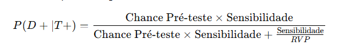

Fatorando a sensibilidade no denominador, temos que:

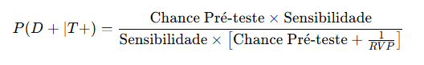

Cancelando a sensibilidade do numerador e do denominador, temos:

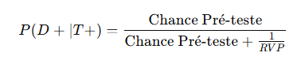

Multiplicando numerador e denominador por RVP, temos que:

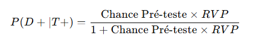

Essa foi então a definição de Probabilidade Pós-Teste

E pela fórmula de chance, a chance pós-teste é:

$Chance pós-teste = \frac{P(D+|T+)}{1 - P(D+|T+)}$

Podemos então substituir a dedução de probabilidade pós-teste na fórmula de chance pós-teste

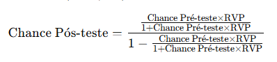

Nesse sentido, podemos simplificar o denominador, da seguinte forma:

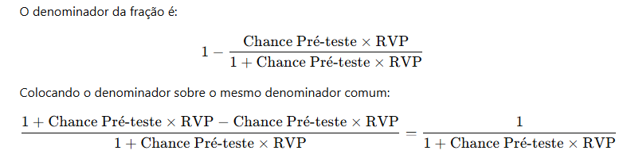

Substituindo o resultado da simplificação por tanto no numerador quanto no denominador de (1 + Chance Pré-teste * RVP), a expressão da chance pós-teste fica:

$\ Chance Pós-teste = Chance pré-teste * RVP$

Essa é a fórmula de chance pós-teste deduzida!

O mesmo se encontrará para RVN, se deduzido a partir de:

$\Pr( D+ | T -) = \frac{Pr (D+) * Pr(T-|D+)}{P(T-)}$

#### Aplicação da Razão de Verossimilhança

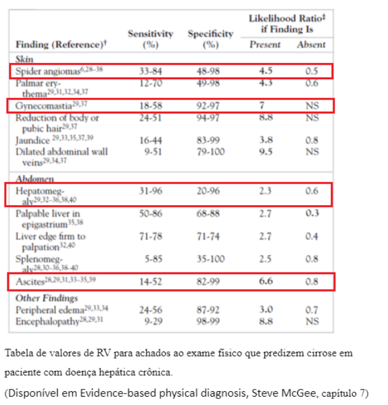

Paciente: Masculino, obeso, admitido no serviço de ortopedia após acidente com queda de caixa sobre a perna, causando fratura instável de tíbia e fíbula distal.

Observações Clínicas: Paciente alerta e hemodinamicamente estável. Hálito alcoólico (observado às 10:00 horas da manhã). Presença de: Ginecomastia. Três aranhas vasculares na parte superior do tronco. Ausência de: Hepatomegalia e ascite.

Calcule a Chance e probabilidade final de cirrose, sabendo que a chance pós-teste de uma cálculo vira a chance pré-teste para o próximo cálculo

$Chance pós-teste = Chance pré-teste * Razão de verossimilhança$

```python
#Prevalência
prevalencia = 0.10

#Chance pré-teste
chance_pre_teste = prevalencia / (1 - prevalencia)
print(chance_pre_teste)
```

```
0.11111111111111112
```

```python
# Razão de verossimilhança
razao_verossimilhanca_positiva_aranhas_vasculares = 4.5
razao_verossimilhanca_positiva_ginecomastia = 7
razao_verossimilhanca_negativa_hepatomegalia = 0.6
razao_verossimilhanca_negativa_ascite = 0.8

# Chance pós-teste
chance_pos_teste_final = chance_pre_teste * razao_verossimilhanca_positiva_aranhas_vasculares * razao_verossimilhanca_positiva_ginecomastia * razao_verossimilhanca_negativa_hepatomegalia * razao_verossimilhanca_negativa_ascite

print("Chance pós-teste:", chance_pos_teste_final)
```

```
Chance pós-teste: 1.6800000000000002
```

Se a chance é a probabilidade sobre seu complementar:

$Chance = \frac{Probabilidade}{1 - Probabilidade}$

A probabilidade é, deduzindo a fórmula:

$Probabilidade = \frac{Chance}{1 + Chance}$

```python
probabilidade_pos_teste = chance_pos_teste_final / (1 + chance_pos_teste_final)

print("Probabilidade pós-teste:", probabilidade_pos_teste)
```

```
Probabilidade pós-teste: 0.6268656716417911
```

**Nomograma de Fagan**

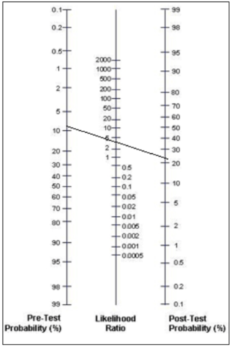

https://ulan.mede.uic.edu/cgi-bin/testcalc.pl

## A tomada de decisão racional

[figure not shown]

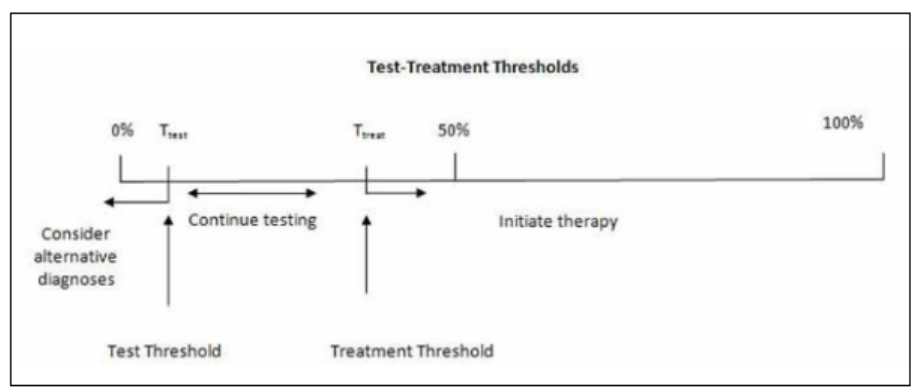

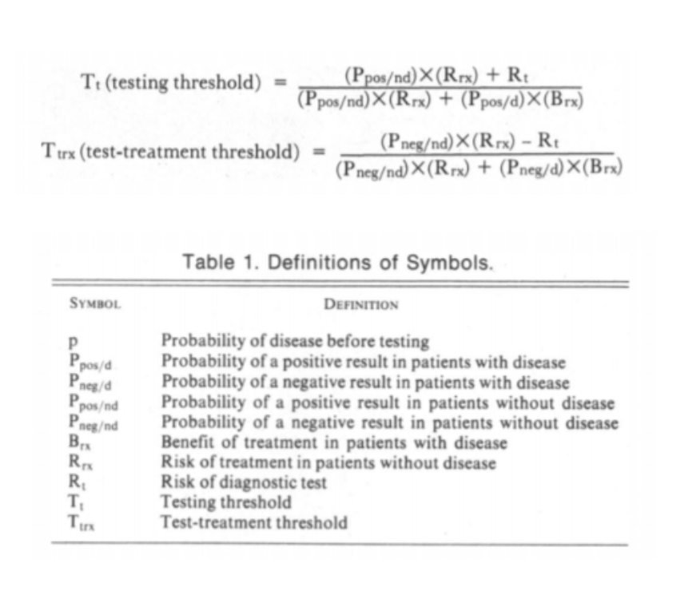